# Eltecon Data Science Course by Emarsys

Introduction to ML

Levente Otti

September 22, 2021

## Goal of the lesson

- Understand what *prediction* is, and how it differs from *causal inference*
- Try basic `R` commands for fitting & evaluating simple regression and classification models

# What is prediction?

You have an assumed relationship:

$$Y \approx f(X) + \epsilon$$

where:

- $Y$ is your target variable
- $X$ are your predictors
- $f()$: is the relationship between $X$ and $Y$
- $\epsilon$: is the irreducible error

**Prediction is**:

- estimating $f()$ based on the available observations ($X$) ...
- **... to minimize the error of $Y$ vs $\hat{Y}$**

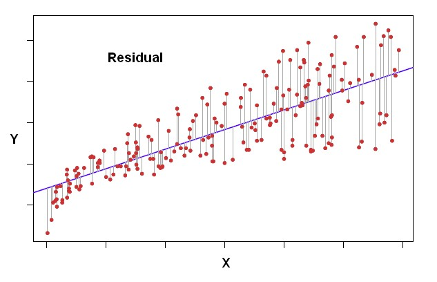

## Error metric: RMSE

- Root Mean Square Error (RMSE)
- It is the standard deviation of the residuals i.e. prediction errors
- RMSE penalizes the model for large errors

$$RMSE = \sqrt{\frac{\sum_{i=1}^n (\hat{y_i}-y_i)^2}{n}}$$

## Bike rental - the dataset

- Source: [Kaggle](https://www.kaggle.com/c/bike-sharing-demand/overview/description)
- Goal: Predict the total count of bikes rented during each hour

| count | season_1 | season_2 | workingday | holiday | hour | weather_1 | weather_2 | temp | atemp | humidity | windspeed |
| --- | --- | --- | --- | --- | --- | --- | --- | --- | --- | --- | --- |
| 16 | TRUE | FALSE | 0 | 0 | 0 | TRUE | FALSE | 9.84 | 14.395 | 81 | 0.0000 |
| 40 | TRUE | FALSE | 0 | 0 | 1 | TRUE | FALSE | 9.02 | 13.635 | 80 | 0.0000 |
| 32 | TRUE | FALSE | 0 | 0 | 2 | TRUE | FALSE | 9.02 | 13.635 | 80 | 0.0000 |
| 13 | TRUE | FALSE | 0 | 0 | 3 | TRUE | FALSE | 9.84 | 14.395 | 75 | 0.0000 |
| 1 | TRUE | FALSE | 0 | 0 | 4 | TRUE | FALSE | 9.84 | 14.395 | 75 | 0.0000 |
| 1 | TRUE | FALSE | 0 | 0 | 5 | FALSE | TRUE | 9.84 | 12.880 | 75 | 6.0032 |

## Bike rental - variables

| field | description |
| --- | --- |
| season | 1 = spring, 2 = summer, 3 = fall, 4 = winter |
| holiday | whether the day is considered a holiday |
| workingday | whether the day is neither a weekend nor holiday |
| weather | 1 ~ Clear, 2 ~ Cloudy, 3 ~ Light Rain, 4 ~ Heavy Rain |
| temp | temperature in Celsius |
| atemp | feels like temperature in Celsius |
| humidity | relative humidity |
| windspeed | wind speed |
| count | number of total rentals |

## Benchmark "model"

```r
calculateRMSE <- function(actual, predictions) {
  sqrt(mean((actual - predictions) ^ 2))
}
```

```r
predictions_benchmark_model <- rep(
  bike_sharing_train[, mean(count)], bike_sharing_train[, .N]
)

bike_sharing_benchmark_model_rmse <- calculateRMSE(
  actual = bike_sharing_train$count,
  predictions = predictions_benchmark_model
)

bike_sharing_benchmark_model_rmse
```

```
## [1] 170.2384
```

# Regression

## Linear regression

When to use it:

- We want to estimate a numerical target (e.g. price)
- Assuming an approximate linear relationship between $X$ and $Y$

Simple linear regression formula:

$$\hat{Y} = \beta_0 + \beta_1 X$$

The OLS estimation of $\beta$ will conveniently minimize RMSE for given $X$!

## (So what is Machine Learning?)

```r
bike_sharing_min_model <- glm(
  formula = count ~ atemp, #target variable ~ feature variables
  family = gaussian,
  data = bike_sharing_train
)
```

## Bike rental - minimal model

```r
summary(bike_sharing_min_model)
```

```
##
## Call:
## glm(formula = count ~ atemp, family = gaussian, data = bike_sharing_train)
##
## Deviance Residuals:
##     Min       1Q   Median       3Q      Max
## -282.73  -103.86   -27.63    72.96   709.89
##
## Coefficients:
##             Estimate Std. Error t value Pr(>|t|)
## (Intercept) -19.5412     4.6755   -4.18 2.95e-05 ***
## atemp         8.3048     0.1841   45.10  < 2e-16 ***
## ---
## Signif. codes:  0 '***' 0.001 '**' 0.01 '*' 0.05 '.' 0.1 ' ' 1
##
## (Dispersion parameter for gaussian family taken to be 23649.64)
##
##     Null deviance: 261264747  on 9014  degrees of freedom
## Residual deviance: 213154213  on 9013  degrees of freedom
## AIC: 116378
##
## Number of Fisher Scoring iterations: 2
```

## Bike rental - minimal model - coefficients

```r
str(bike_sharing_min_model$coefficients)
```

```
##  Named num [1:2] -19.5 8.3
##  - attr(*, "names")= chr [1:2] "(Intercept)" "atemp"
```

```r
intercept <- bike_sharing_min_model$coefficients[1]
slope <- bike_sharing_min_model$coefficients[2]
```

## Bike rental - minimal model - predictive fit

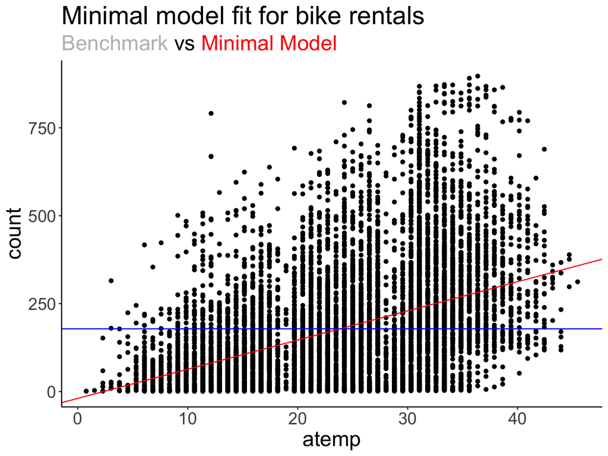

## Bike rental - minimal model - prediction error

```r
predictions_min_model <- predict.glm(
  bike_sharing_min_model, newdata = bike_sharing_train
)

predictions_min_model[1:5]
```

```
##         1         2         3         4         5
## 100.00620  93.69456  93.69456 100.00620 100.00620
```

```r
bike_sharing_train[1:5, count]
```

```
## [1] 16 40 32 13  1
```

## Bike rental - minimal model - prediction error

```r
calculateRMSE <- function(actual, predictions) {
  sqrt(mean((actual - predictions) ^ 2))
}
```

```r
bike_sharing_min_model_rmse <- calculateRMSE(
  actual = bike_sharing_train[, count],
  predictions = predictions_min_model
)

bike_sharing_min_model_rmse
```

```
## [1] 153.7673
```

## Bike rental - improving predictions

```r
bike_sharing_2nd_model <- glm(
  formula = count ~ atemp + humidity,
  data = bike_sharing_train
)

predictions_2nd_model <- predict.glm(
  bike_sharing_2nd_model, newdata = bike_sharing_train
)

calculateRMSE(
  actual = bike_sharing_train[, count],
  predictions = predictions_2nd_model
)
```

```
## [1] 144.5333
```

## Practice time

- Task: improve the model to be as accurate as possible!
- Share your regression formula + achieved RMSE in [Socrative](https://www.socrative.com/#login)!
- You have 20 minutes - feel free to take a break if needed.

## Practice time

DEMO

## Prediction vs causality (Confounding)

[figure not shown]

## Don't worry about Confounding!

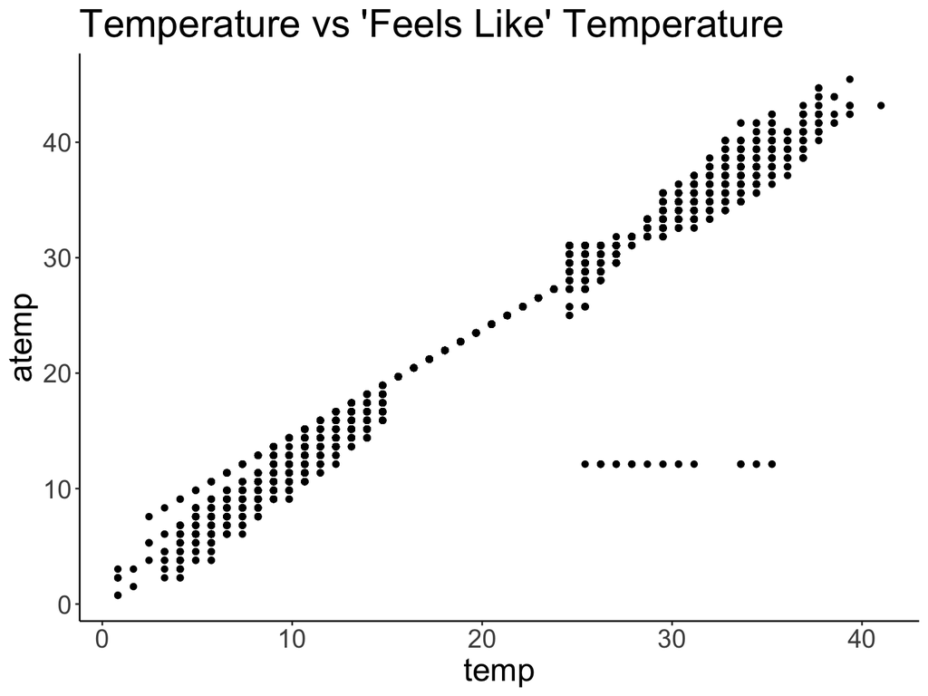

## Why should you still care about model inputs?

- Model explainability is often desirable in business (and other applications)
- Example: [Amazon Sexist Hiring AI](https://www.imd.org/research-knowledge/articles/amazons-sexist-hiring-algorithm-could-still-be-better-than-a-human/)
- In Emarsys: all models are retrained every 30 days
- This ensures that any shifts in user behavior are promptly captured
- E.g. before / after Black Friday

# Classification

## Binary classification

- Binary: target can take on two values (0 or 1)
- Typical example is predicting if an event is happening or not
- Examples:
- Patient has a medical condition or not
- Loan will be repaid in full
- User will make a purchase in the next 30 days (BPS - Buying Probability Score)

## Question time

- **Why should we not use linear regression for binary classification**?
- Please record your answers in [Socrative](https://www.socrative.com/#login)!
- You have 5 minutes

## Logistic regression

- A linear model makes continuous predictions that are unbounded.
- In classification, we are interested in the probability of an outcome occurring
- So we want **predictions that are bounded between 0 and 1.**

$$Pr(Y_i=1|X_i) = {\frac{exp(\beta_0 + \beta_1X_i)}{1 + exp (\beta_0 + \beta_1X_i)}}$$

## The sigmoid function

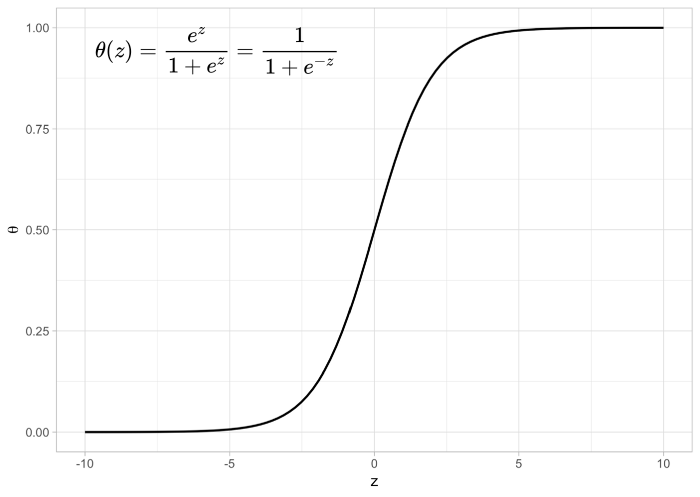

## The Titanic dataset

```r
install.packages("titanic")
library(titanic)
head(titanic_train)
```

| PassengerId | Survived | Pclass | Name | Sex | Age | SibSp | Parch | Ticket | Fare | Cabin | Embarked |
| --- | --- | --- | --- | --- | --- | --- | --- | --- | --- | --- | --- |
| 1 | 0 | 3 | Braund, Mr. Owen Harris | male | 22 | 1 | 0 | A/5 21171 | 7.2500 |  | S |
| 2 | 1 | 1 | Cumings, Mrs. John Bradley (Florence Briggs Thayer) | female | 38 | 1 | 0 | PC 17599 | 71.2833 | C85 | C |
| 3 | 1 | 3 | Heikkinen, Miss. Laina | female | 26 | 0 | 0 | STON/O2. 3101282 | 7.9250 |  | S |
| 4 | 1 | 1 | Futrelle, Mrs. Jacques Heath (Lily May Peel) | female | 35 | 1 | 0 | 113803 | 53.1000 | C123 | S |
| 5 | 0 | 3 | Allen, Mr. William Henry | male | 35 | 0 | 0 | 373450 | 8.0500 |  | S |
| 6 | 0 | 3 | Moran, Mr. James | male | NA | 0 | 0 | 330877 | 8.4583 |  | Q |

## Example - binary model

```r
model <- glm(
    Survived ~ Fare,
    data = titanic_train,
    family = binomial(link = "logit")
)
```

## Making predictions

```r
predicted_prob <- predict.glm(
  model,
  newdata = titanic_train,
  type = "response"
)

predicted_prob[1:5]
```

```
##         1         2         3         4         5
## 0.3034014 0.5354287 0.3055738 0.4664564 0.3059770
```

## Predictive fit

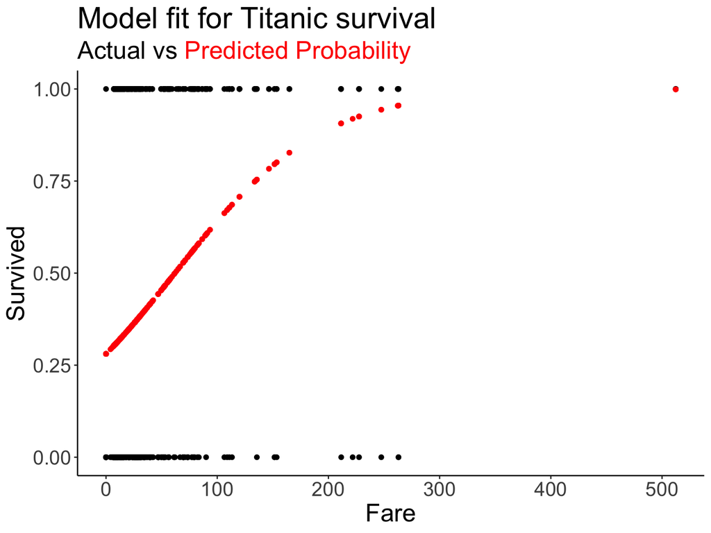

## Converting probabilities to predictions

```r
titanic_train[1:5, "Survived"]
```

```
## [1] 0 1 1 1 0
```

**Using `cutoff = 0.5`:**

```r
predicted_class <- ifelse(predicted_prob > 0.5, 1, 0)
predicted_class[1:5]
```

```
## 1 2 3 4 5
## 0 1 0 0 0
```

## Evaluating binary models - Accuracy

```r
calculateAccuracy <- function(actual, predicted) {
    return( sum(actual == predicted) / length(actual) )
}
```

```r
calculateAccuracy(titanic_train$Survived, predicted_class)
```

```
## [1] 0.6655443
```

## Evaluating binary models - Confusion Matrix

```r
table(
  predicted_class,
  titanic_train$Survived,
  dnn = c( "predicted", "actual")
)
```

```
##          actual
## predicted   0   1
##         0 511 260
##         1  38  82
```

## Practice time

- Task: improve the model to be as accurate as possible!
- Share your regression formula + achieved Accuracy & Confusion Matrix in [Socrative](https://www.socrative.com/#login)!
- You have 20 minutes - feel free to take a break if needed.

## Practice time

DEMO

# Generalization performance

## Why do we care?

- It's easy to predict something we already know...
- Actually, it would be silly to build predictive models to predict what we already know!
- What we are after is **out-of-sample** performance

## Example on the Bike Sharing dataset

```r
simple_model <- glm(
  count ~ hour + temp + workingday,
  data = bike_sharing_train
)
```

## Accuracy on our training data

```r
simple_model_predictions <- predict.glm(
  simple_model,
  newdata = bike_sharing_train
)

calculateRMSE(bike_sharing_train$count, simple_model_predictions)
```

```
## [1] 141.4175
```

## Accuracy out-of-sample

```r
bike_sharing_test <- fread("bike_sharing_test.csv")

simple_model_predictions <- predict.glm(
  simple_model,
  newdata = bike_sharing_test
)

calculateRMSE(bike_sharing_test$count, simple_model_predictions)
```

```
## [1] 208.0325
```

# Homework

## Homework - prediction

- Find an interesting example for Prediction vs causality issue
- Find the relevant data and visualise it